# Tutorial: Deep Learning con R

Catherine Rincón

2023-11-24

## **Resumen**

Este tutorial es una introducción a Deep Learning y tiene como objetivo brindar los conceptos básicos, su importancia en la inteligencia artificial y las ventajas de su implementación. En la sesión se explicará el funcionamiento básico de una red neuronal a través de un ejemplo sencillo de clasificación de imágenes, implementando los frameworks de TensorFlow y Keras en R. Para esto, se mostrará un paso a paso con cada una de las etapas que se requieren dentro del proceso de análisis de datos: cargar y preprocesar los datos, teniendo en cuenta la normalización y la división de los datos en dos conjuntos: Datos de entrenamiento y prueba.

Creación de una red neuronal sencilla con sus respectivas capas y función de activación, utilizando Keras. Configuración del proceso de entrenamiento, incluyendo la elección de la función de pérdida y el optimizador. Además, se realizarán procesos de compilación del modelo creado, entrenamiento con sus respectivos datos y evaluación del modelo a partir de métricas que permitan validar la precisión del modelo predictivo.

## **Parte 1:** Introducción a Deep Learning

- Definición de AI, ML, DL
- Importancia del DL y campos de aplicación
- Redes neuronales y sus componentes
- Tipos de redes neuronales

### Definición de AI, ML & DL y sus diferencias

[figure not shown]

**Inteligencia Artificial (AI):** Es una rama de la informática que busca automatizar tareas o imitar comportamientos normalmente realizadas por los humanos.

**Machine Learning (ML):** Es una rama de la AI, que hace que un sistema descubra (aprenda) automáticamente la estructura estadística de los datos y convierta estos patrones para acercarse al resultado esperado (Ghatak, 2019). Taxonomía de problemas de ML: - Aprendizaje supervisado - Aprendizaje no supervisado - Aprendizaje por refuerzo

**Deep Learning (DL):** Es una rama del ML, una nueva visión del aprendizaje de representaciones a partir de datos que pone énfasis en el aprendizaja de capas sucesivas de representaciones cada vez más significativas (Entre más capas, más abstracta la información) (Chollet & Allaire, 2017).

### Importancia del DL y campos de aplicación

- Reconocimiento de caracteres, imágenes, voz
- Clasificación de imágenes
- Traducción de texto a voz, de idiomas
- Procesamiento de lenguaje natural (NLP)
- Generación de texto
- Predicciones en diferentes campos
- Análisis genético
- comprender ciertos fenómenos neurofisiológicos (Neurociencia)
- Detección de enfermedades (Medicina)
- Clasificación morfológica de las galaxias (Astrofísica)

### Redes Neuronales y sus componentes

Las redes neuronales tratan de simular el mecanismo de aprendizaje de organismos biológicos a través de la imitación de una neurona biológica (Aggarwal, 2018). La red neuronal simple es conocida como perceptrón y se caracteriza por tener una sola capa de entrada y un capa de salida.

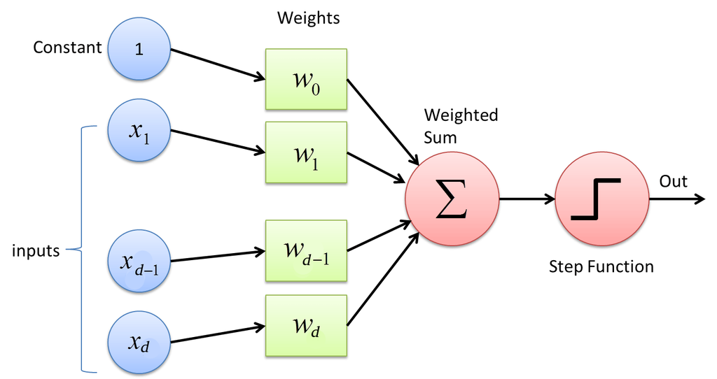

Componentes de una red neuronal:

- Entradas
- Bias
- Conexiones y pesos asociados
- **Nodo o neurona:** Unidad básica de procesamiento de una red neuronal. Estos nodos se organizan en capas:
  - La primera capa se llama *capa de entrada*
  - Las capas del medio se conocen como *capas ocultas*
  - La última se llama *capa de salida*
- **Función de activación:** La función de activación también es uno de los hiperparámetros de una red neuronal y se define como una función matemática que transforma los datos de entrada, activando una señal de salida cuando se ha alcanzado un umbral de entrada específico (Dinov, 2018; Ghatak, 2019). Existen diferentes funciones de activación que se pueden implementar en las redes neuronales, estas funciones de activación pueden ser lineales y no lineales (Ghatak, 2019; Pawlus & Devine, 2020). La función de activación lineal es una línea recta y su salida oscila entre [-∞,+∞], sin embargo, este tipo de funciones no ayudan con la complejidad de los datos y los parámetros de las redes neuronales (Aggarwal, 2018; Ghatak, 2019). Las funciones de activación no lineales ayudan a la simulación de la mayoría de problemas del mundo real, las cuales toman cualquier entrada de [-∞,+∞] y asignarla a una salida que oscila entre [0,1] y [-1,1] (Aggarwal, 2018; Ghatak, 2019).

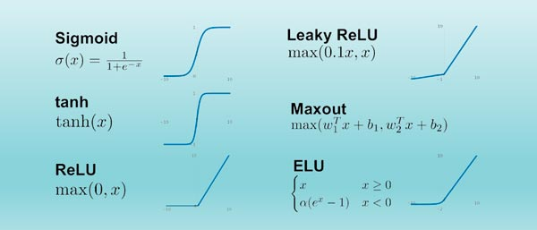

- Salida

### **Tipos de redes neuronales**

Existen diferentes tipos de arquitecturas de redes neuronales que se pueden clasificar de acuerdo a su estructura, tipo de neurona, entre otros.

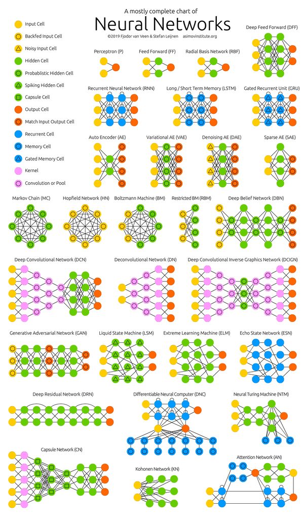

## **Parte 2:** Ejemplo de Deep Learning en R

- Keras en R
- Base de datos a analizar
- Ejemplo
  - Instalar los paquetes necesarios
  - Cargar los datos
  - Dividir los datos en dos conjuntos
  - Realizar el preprocesamiento de los datos
  - Definir la estructura del modelo con la red neuronal
  - Compilar el modelo
  - Entrenar el modelo
  - Evaluar el desempeño del modelo
  - Generar predicciones

### Keras en R

Keras es una API (Application Programming Interface) de alto nivel para crear y entrenar modelos de aprendizaje profundo. Se utiliza para la creación rápida de prototipos, investigación avanzada y en producción. Las ventajas clave de Keras son:

- *Fácil de usar (amigable con el usuario):* Keras tiene una interfaz simple y consistente, optimizada para casos de uso comunes. Proporciona información clara y procesable sobre los errores del usuario.
- *Modular y configurable:* Los modelos en Keras se fabrican conectando bloques de construcción configurables entre sí, con pocas restricciones.
- *Fácil de extender:* Escribir bloques de construcción personalizados para expresar nuevas ideas para la investigación. Cree nuevas capas, funciones de pérdida y desarrolle modelos de última generación.

### Base de datos a analizar

**MNIST** (Modified National Institute of Standards and Technology) es una base de datos de imágenes de números del 0 al 9 escritos a mano en escala de grises (0-255) con un tamaño de 28x28, es decir, 784 píxeles. Es un subconjunto de una base de datos especial 3 del NIST (dígitos escritos por empleados de la Oficina del Censo de Estados Unidos) y una base de datos especial 1 (dígitos escritos por estudiantes de secundaria).

*Objetivo:* Predecir el número escrito a mano de la imagen.

La base de datos cuenta con 70.000 imágenes que se dividen en dos conjuntos de datos: - Datos de entrenamiento - Datos de prueba

Cada uno de los conjuntos de datos cuenta con dos componentes: - Imágenes - Etiquetas

https://knowyourdata-tfds.withgoogle.com/#tab=STATS&dataset=mnist

### **Ejemplo**

Para el desarrollo se tiene en cuenta los siguientes pasos: - Instalar los paquetes

- Cargar los datos
- Dividir los datos en dos conjuntos de datos
- Realizar el preprocesamiento de los datos
- Definir la estructura del modelo con la red neuronal
- Compilar el modelo
- Entrenar el modelo
- Evaluar el desempeño del modelo
- Generar predicciones

#### *Instalar los paquetes necesarios*

Se instalan y disponibilizan los paquetes necesarios para el desarrollo del ejemplo.

#### *Cargar los datos*

```r
# Cargar el conjunto de datos MNIST
mnist <- dataset_mnist()

names(mnist)
```

```
## [1] "train" "test"
```

```r
cat("Entenamiento:", names(mnist$train), "- prueba:", names(mnist$test))
```

```
## Entenamiento: x y - prueba: x y
```

#### *Dividir los datos en dos conjuntos*

```r
# Datos de entrenamiento
x_train <- mnist$train$x
y_train <- mnist$train$y

# Datos de prueba
x_test <- mnist$test$x
y_test <- mnist$test$y

# Para evaluar el modelo
y_true <- mnist$test$y

# Dimensiones de los datos de entrenamieto y prueba
cat("x entenamiento: ", dim(x_train), "- y entrenamiento", dim(y_train))
```

```
## x entenamiento:  60000 28 28 - y entrenamiento 60000
```

```r
cat("x prueba: ", dim(x_test), "- y prueba", dim(y_test))
```

```
## x prueba:  10000 28 28 - y prueba 10000
```

En el conjunto de datos de entrenamiento se tienen 60.000 imágenes de 28 x 28. Lo que indica una matriz de 28 filas por 28 columnas que contiene diferentes números, el cero representa que no se escribió nada y entre más grande el número, indica una marca más obscura en la imagen.

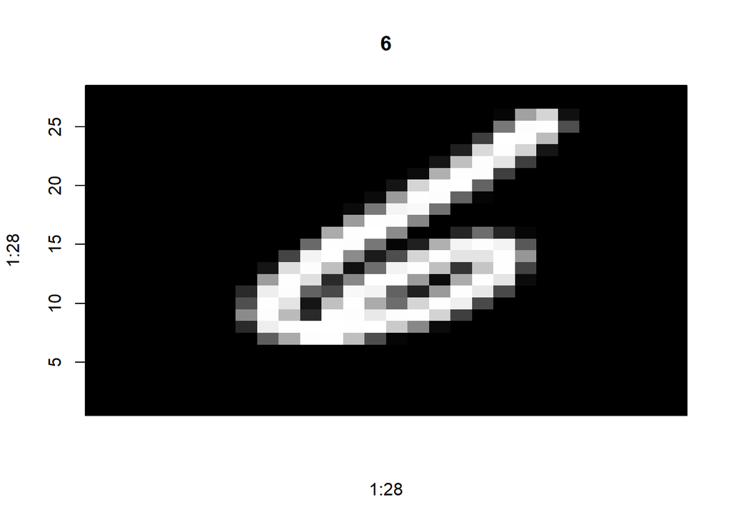

```r
# Visualización de la imagen 1000 del conjunto de datos de entrenamiento
im <- x_train[1000, , ]
im <- t(apply(im, 2, rev))
image(x=1:28, y=1:28, z=im, col=gray((0:255)/255),
          xaxt='n', main=paste(y_train[1000]))
```

```r
# Visualización de la imagen en forma de matriz del conjunto de datos de entrenamiento
x_train[1000, , ]
```

```
##       [,1] [,2] [,3] [,4] [,5] [,6] [,7] [,8] [,9] [,10] [,11] [,12] [,13]
##  [1,]    0    0    0    0    0    0    0    0    0     0     0     0     0
##  [2,]    0    0    0    0    0    0    0    0    0     0     0     0     0
##  [3,]    0    0    0    0    0    0    0    0    0     0     0     0     0
##  [4,]    0    0    0    0    0    0    0    0    0     0     0     0     0
##  [5,]    0    0    0    0    0    0    0    0    0     0     0     0     0
##  [6,]    0    0    0    0    0    0    0    0    0     0     0     0     0
##  [7,]    0    0    0    0    0    0    0    0    0     0     0     0     0
##  [8,]    0    0    0    0    0    0    0    0    0     0     0     0     0
##  [9,]    0    0    0    0    0    0    0    0    0     0     0     0     0
## [10,]    0    0    0    0    0    0    0    0    0     0     0     0     0
## [11,]    0    0    0    0    0    0    0    0    0     0     0     0    11
## [12,]    0    0    0    0    0    0    0    0    0     0     0     0   155
## [13,]    0    0    0    0    0    0    0    0    0     0     0   171   254
## [14,]    0    0    0    0    0    0    0    0    0     0   105   254   253
```

[output cut: 72 more lines]

```r
# Visualización de la etiqueta
y_train[1000]
```

```
## [1] 6
```

Los primeros 16 números del conjunto de datos de entrenamiento se visualizan de la siguente forma:

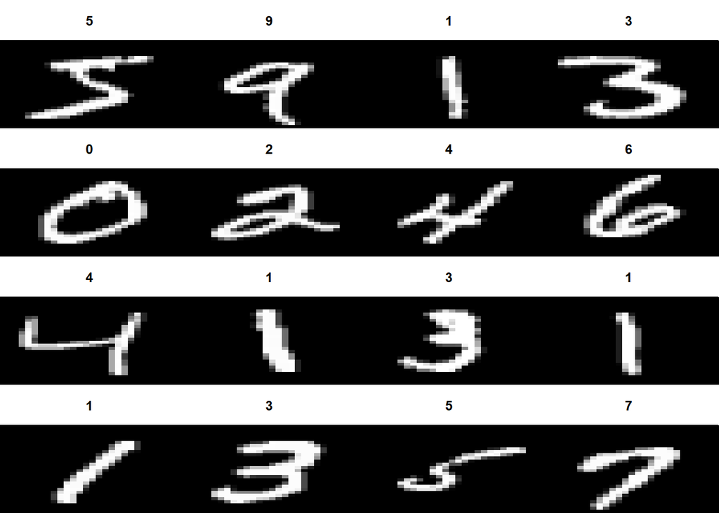

```r
par(mfcol=c(4, 4))
par(mar=c(0, 0, 3, 0), xaxs='i', yaxs='i')
for (j in 1:16) {
    im <- x_train[j, , ]
    im <- t(apply(im, 2, rev))
    image(x=1:28, y=1:28, z=im, col=gray((0:255)/255),
          xaxt='n', main=paste(y_train[j]))
}
```

```r
# Las etiquetas de los números
y_train[1:16]
```

```
##  [1] 5 0 4 1 9 2 1 3 1 4 3 5 3 6 1 7
```

#### *Realizar el preprocesamiento de los datos*

Se tienen diferentes imágenes de tamaño 28x28 píxeles en escala de grises de varios números. Para la preparación de los datos se debe realizar:

- Aplanamiento de las imágenes 28x28 a un vector 1x784.
- Estas imágenes están representadas a través de una matriz que define el número de cada imagen en un rango entre 0 y 255. Por lo cual, se deben normalizar las imágenes para tener las matrices en un rango entre 0 y 1.

```r
# Preprocesar los datos
x_train <- array_reshape(x_train, c(nrow(x_train), 784))
x_test <- array_reshape(x_test, c(nrow(x_test), 784))

# Normalizar los valores de píxeles en el rango [0, 1]
x_train <- x_train/255
x_test <- x_test/255
```

#### *Definir la estructura del modelo con la red neuronal*

```r
# Definir el modelo
model <- keras_model_sequential() %>%
  layer_dense(units = 256, activation = 'relu', input_shape = c(784)) %>%
  layer_dropout(rate = 0.4) %>%
  layer_dense(units = 128, activation = 'relu') %>%
  layer_dropout(rate = 0.3) %>%
  layer_dense(units = 10, activation = 'softmax')

summary(model)
```

```
## Model: "sequential"
## ________________________________________________________________________________
##  Layer (type)                       Output Shape                    Param #
## ================================================================================
##  dense_2 (Dense)                    (None, 256)                     200960
##  dropout_1 (Dropout)                (None, 256)                     0
##  dense_1 (Dense)                    (None, 128)                     32896
##  dropout (Dropout)                  (None, 128)                     0
##  dense (Dense)                      (None, 10)                      1290
## ================================================================================
## Total params: 235,146
## Trainable params: 235,146
## Non-trainable params: 0
## ________________________________________________________________________________
```

El modelo anterior tiene 235.146 parámetros. El número de parámetros se define de acuerdo al número de neuronas que se tienen en cada una de las capas:

Entrada a Capa 1 Densa: 784*256 + 256 (bias) = 200.960

Capa 1 Dropout

Capa 2 Densa: 256*128 + 128 (bias) = 32.896

Capa 2 Dropout

Capa 3 Densa a Salida: 128*10 + 10 (bias) = 1.290

Total parámetros = 235.146

#### *Compilar el modelo*

La compilación del modelo se puede realizar con:

- Funciones de pérdida
  - sparse_categorical_crossentropy
  - categorical_crossentropy
- Optimizador
  - adam
  - optimizer_rmsprop

```r
# Compilar el modelo
model %>% compile(
  loss = 'sparse_categorical_crossentropy',
  optimizer = 'adam',
  metrics = c('accuracy')
)
```

#### *Entrenar el modelo*

El entrenamiento del modelo se realiza a partir de la función fit() y se puede almacenar en una variable con el fin de ver el entrenamiento del modelo. Además, se puede agregar el parámetro *validation_split* con el fin de generar un conjunto de validación con el objetivo de evaluar el desempeño del modelo.

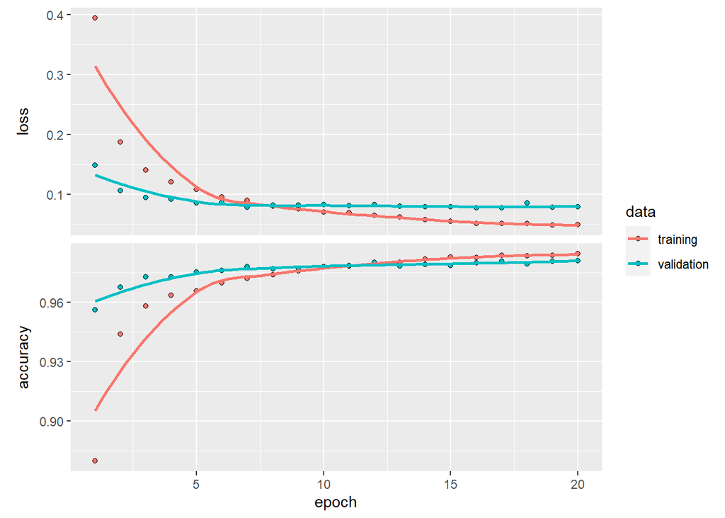

```r
# Entrenar el modelo
training <- model %>% fit(x_train,
              y_train,
              epochs = 20,
              batch_size = 64,
              validation_split = 0.2)

plot(training)
```

#### *Evaluar el desempeño del modelo*

```r
# Evaluar el modelo en el conjunto de prueba
eval <- model %>% evaluate(x_test, y_test)
eval
```

```
##       loss   accuracy
## 0.07921588 0.97850001
```

#### *Generar predicciones*

```r
# Realizar predicciones y generar matriz de confusion
prediction <- model %>% predict(x_test) %>% k_argmax()

# Se realiza la matriz de confusion
matriz_confusion <- table(as.array(prediction), y_true)
matriz_confusion
```

```
##    y_true
##        0    1    2    3    4    5    6    7    8    9
##   0  972    0    4    0    1    2    2    1    4    1
##   1    1 1126    1    0    0    0    3    3    0    4
##   2    0    2 1013    6    4    0    0   13    3    0
##   3    2    2    2  993    0   11    1    3    6   12
##   4    0    0    1    0  960    1    3    1    5    7
##   5    0    1    0    4    0  862    6    0    4    4
##   6    1    1    1    0    4    8  940    0    1    1
##   7    1    0    5    4    3    1    0 1003    3    6
##   8    3    3    5    2    1    3    3    1  945    3
##   9    0    0    0    1    9    4    0    3    3  971
```

```r
accuracy <- sum(diag(matriz_confusion)) / sum(matriz_confusion)
accuracy
```

```
## [1] 0.9785
```

```r
# Números de la predicción
prediction$numpy()
```

```
##     [1] 7 2 1 0 4 1 4 9 6 9 0 6 9 0 1 5 9 7 3 4 9 6 6 5 4 0 7 4 0 1 3 1 3 4 7 2
##    [37] 7 1 2 1 1 7 4 2 3 5 1 2 4 4 6 3 5 5 6 0 4 1 9 5 7 8 9 3 7 4 6 4 3 0 7 0
##    [73] 2 9 1 7 3 2 9 7 7 6 2 7 8 4 7 3 6 1 3 6 9 3 1 4 1 7 6 9 6 0 5 4 9 9 2 1
##   [109] 9 4 8 7 3 9 7 4 4 4 9 2 5 4 7 6 4 9 0 5 8 5 6 6 5 7 8 1 0 1 6 4 6 7 3 1
##   [145] 7 1 8 2 0 2 9 9 5 5 1 5 6 0 3 4 4 6 5 4 6 5 4 5 1 4 4 7 2 3 2 7 1 8 1 8
##   [181] 1 8 5 0 8 9 2 5 0 1 1 1 0 9 0 3 1 6 4 2 3 6 1 1 1 3 9 5 2 9 4 5 9 3 9 0
##   [217] 3 5 5 5 7 2 2 7 1 2 8 4 1 7 3 3 8 8 7 9 2 2 4 1 5 9 8 7 2 3 0 2 4 2 4 1
##   [253] 9 5 7 7 2 8 2 6 8 5 7 7 9 1 8 1 8 0 3 0 1 9 9 4 1 8 2 1 2 9 7 5 9 2 6 4
##   [289] 1 5 8 2 9 2 0 4 0 0 2 8 4 7 1 2 4 0 2 7 4 3 3 0 0 3 1 9 6 5 2 5 9 7 9 3
##   [325] 0 4 2 0 7 1 1 2 1 5 3 3 9 7 8 6 3 6 1 3 8 1 0 5 1 3 1 5 5 6 1 8 5 1 7 9
##   [361] 4 6 2 2 5 0 6 5 6 3 7 2 0 8 8 5 4 1 1 4 0 7 3 7 6 1 6 2 1 9 2 8 6 1 9 5
##   [397] 2 5 4 4 2 8 3 8 2 4 5 0 3 1 7 7 5 7 9 7 1 9 2 1 4 2 9 2 0 4 9 1 4 8 1 8
##   [433] 4 5 9 8 8 3 7 6 0 0 3 0 2 0 6 9 9 3 3 3 2 3 9 1 2 6 8 0 5 6 6 6 3 8 8 2
##   [469] 7 5 8 9 6 1 8 4 1 2 5 9 1 9 7 5 4 0 8 9 9 1 0 5 2 3 7 0 9 4 0 6 3 9 5 2
##   [505] 1 3 1 3 6 5 7 4 2 2 6 3 2 6 5 4 8 9 7 1 3 0 3 8 3 1 9 3 4 4 6 4 2 1 8 2
```

[output cut: 263 more lines]

```r
# Números reales
y_test
```

```
##     [1] 7 2 1 0 4 1 4 9 5 9 0 6 9 0 1 5 9 7 3 4 9 6 6 5 4 0 7 4 0 1 3 1 3 4 7 2
##    [37] 7 1 2 1 1 7 4 2 3 5 1 2 4 4 6 3 5 5 6 0 4 1 9 5 7 8 9 3 7 4 6 4 3 0 7 0
##    [73] 2 9 1 7 3 2 9 7 7 6 2 7 8 4 7 3 6 1 3 6 9 3 1 4 1 7 6 9 6 0 5 4 9 9 2 1
##   [109] 9 4 8 7 3 9 7 4 4 4 9 2 5 4 7 6 7 9 0 5 8 5 6 6 5 7 8 1 0 1 6 4 6 7 3 1
##   [145] 7 1 8 2 0 2 9 9 5 5 1 5 6 0 3 4 4 6 5 4 6 5 4 5 1 4 4 7 2 3 2 7 1 8 1 8
##   [181] 1 8 5 0 8 9 2 5 0 1 1 1 0 9 0 3 1 6 4 2 3 6 1 1 1 3 9 5 2 9 4 5 9 3 9 0
##   [217] 3 6 5 5 7 2 2 7 1 2 8 4 1 7 3 3 8 8 7 9 2 2 4 1 5 9 8 7 2 3 0 4 4 2 4 1
##   [253] 9 5 7 7 2 8 2 6 8 5 7 7 9 1 8 1 8 0 3 0 1 9 9 4 1 8 2 1 2 9 7 5 9 2 6 4
##   [289] 1 5 8 2 9 2 0 4 0 0 2 8 4 7 1 2 4 0 2 7 4 3 3 0 0 3 1 9 6 5 2 5 9 2 9 3
##   [325] 0 4 2 0 7 1 1 2 1 5 3 3 9 7 8 6 5 6 1 3 8 1 0 5 1 3 1 5 5 6 1 8 5 1 7 9
##   [361] 4 6 2 2 5 0 6 5 6 3 7 2 0 8 8 5 4 1 1 4 0 3 3 7 6 1 6 2 1 9 2 8 6 1 9 5
##   [397] 2 5 4 4 2 8 3 8 2 4 5 0 3 1 7 7 5 7 9 7 1 9 2 1 4 2 9 2 0 4 9 1 4 8 1 8
##   [433] 4 5 9 8 8 3 7 6 0 0 3 0 2 6 6 4 9 3 3 3 2 3 9 1 2 6 8 0 5 6 6 6 3 8 8 2
##   [469] 7 5 8 9 6 1 8 4 1 2 5 9 1 9 7 5 4 0 8 9 9 1 0 5 2 3 7 8 9 4 0 6 3 9 5 2
##   [505] 1 3 1 3 6 5 7 4 2 2 6 3 2 6 5 4 8 9 7 1 3 0 3 8 3 1 9 3 4 4 6 4 2 1 8 2
```

[output cut: 263 more lines]

## **Referencias**

Aggarwal, C. C. (2018). Neural Networks and Deep Learning. Neural Networks and Deep Learning. https://doi.org/10.1007/978-3-319-94463-0

Chollet, F., & Allaire, J. J. (2016). Deep Learning in R. In R-bloggers (Vol. 1, Issue 7080). https://www.r-bloggers.com/deep-learning-in-r-2/

Ghatak, A. (2019). Deep learning with R. Deep Learning with R, 1–245. https://doi.org/10.1007/978-981-13-5850-0/COVER

Van Veen, F. (2016). The Neural Network Zoo. https://www.asimovinstitute.org/neural-network-zoo/

**Otras Referencias**

Guía básica de Keras: https://tensorflow.rstudio.com/guides/keras/basics

Ejemplo de MNIST: https://rpubs.com/fhernanb/keras_mnist

Fundamentos de Deep Learning: https://rramosp.github.io/2021.deeplearning/intro.html